# Validation set vs training set LDA training - Approach one

```r
library(ggplot2)
library(dplyr)
library(tidyr)
library("ggpubr")
```

This experiment focuses on the question, whether training combining method on the same set of data as the neural networks were trained on has any adverse effects to the performance of the ensemble as opposed to training on a different set, not presented to the networks during the training. Experiment was performed with two slightly different approaches.

Aproach one Experiment code is in the file base_ensembling_experiment.py. Experiment on CIFAR10 dataset. This experiment was performed in 30 replications. In each replication a set of 500 samples from CIFAR10 training set was randomly chosen, with each class represented equally, this set is referred to as validation set. This set was extracted from the CIFAR10 training set. Three neural networks were trained on the reduced training set. These networks were then combined using WeightedLinearEnsemble. For each replication, the ensemble was built twice. First linear combining method was trained on the extracted validation set and second on a randomly chosen set of 500 samples from the neural networks training set. These linear combining method training sets are referred to as vt and tt respectively.

Approach two is described and visualized in files visualization_half_train_base_experiment_CIF10 and visualization_half_train_base_experiment_CIF100.

```r
net_results <- read.csv("../data/data_train_val_c10/net_accuracies.csv")
ens_results <- read.csv("../data/data_train_val_c10/ensemble_accuracies.csv")
```

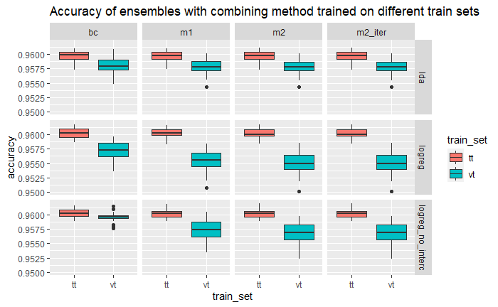

```r
box_acc <- ggplot() + geom_boxplot(data=ens_results, mapping = aes(x=train_set, y=accuracy, fill=train_set)) +
  facet_grid(rows=vars(combining_method), cols=vars(coupling_method)) +
  ggtitle("Accuracy of ensembles with combining method trained on different train sets")
box_acc
```

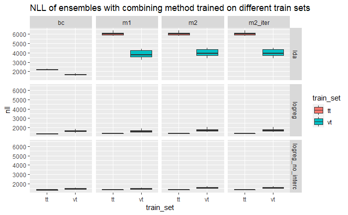

```r
box_nll <- ggplot() + geom_boxplot(data=ens_results, mapping = aes(x=train_set, y=nll, fill=train_set)) +
  facet_grid(rows=vars(combining_method), cols=vars(coupling_method)) +
  ggtitle("NLL of ensembles with combining method trained on different train sets")
box_nll
```

For some reason, when using lda, NLL has opposite trend to accuracy - train set with better accuracy has worse (larger) NLL. This needs some further attention. For logistic regression, the behavior is as expected.

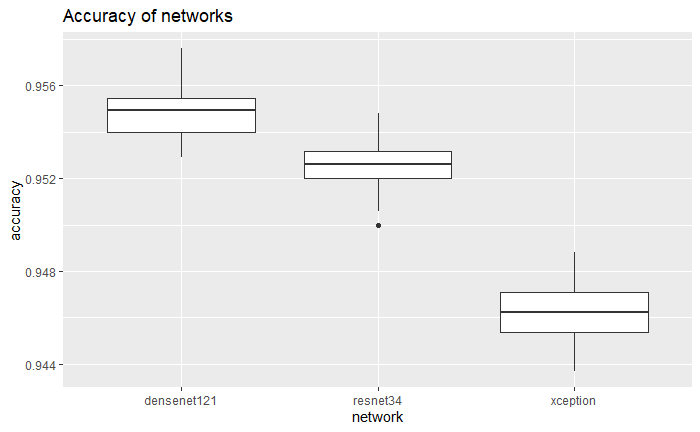

```r
box_net_acc <- ggplot() + geom_boxplot(data=net_results, mapping=aes(x=network, y=accuracy)) +
  ggtitle("Accuracy of networks")
box_net_acc
```

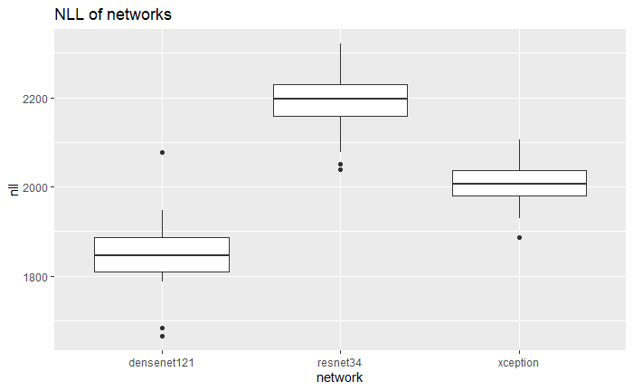

```r
box_net_nll <- ggplot() + geom_boxplot(data=net_results, mapping=aes(x=network, y=nll)) +
  ggtitle("NLL of networks")
box_net_nll
```

## Accuracy

```r
ens_results_wide <- pivot_wider(ens_results, names_from = c(train_set, coupling_method), values_from = c(accuracy, nll))
```

Testing statistical significance of difference for training on validation and train data Since ensembles in each replication are trained on the same set of networks, we use paired t-test.

```r
differences <- data.frame(ens_results_wide$combining_method,
                          ens_results_wide$accuracy_vt_m1 - ens_results_wide$accuracy_tt_m1,
                          ens_results_wide$accuracy_vt_m2 - ens_results_wide$accuracy_tt_m2,
                          ens_results_wide$accuracy_vt_m2_iter - ens_results_wide$accuracy_tt_m2_iter,
                          ens_results_wide$accuracy_vt_bc - ens_results_wide$accuracy_tt_bc,
                          ens_results_wide$nll_vt_m1 - ens_results_wide$nll_tt_m1,
                          ens_results_wide$nll_vt_m2 - ens_results_wide$nll_tt_m2,
                          ens_results_wide$nll_vt_m2_iter - ens_results_wide$nll_tt_m2_iter,
                          ens_results_wide$nll_vt_bc - ens_results_wide$nll_tt_bc)
names(differences) <- c("combining_method", "acc_diff_m1", "acc_diff_m2", "acc_diff_m2_iter", "acc_diff_bc", "nll_diff_m1", "nll_diff_m2", "nll_diff_m2_iter", "nll_diff_bc")
```

Ascertaining normality of differences

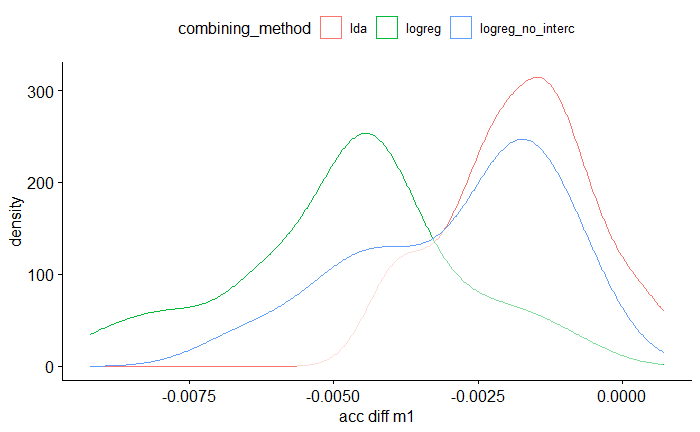

```r
ggdensity(data=differences, x="acc_diff_m1", color="combining_method", xlab="acc diff m1")
```

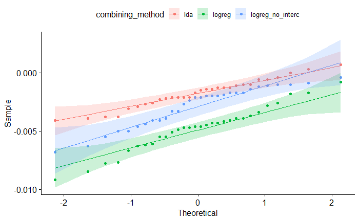

```r
ggqqplot(differences, x="acc_diff_m1", color="combining_method")
```

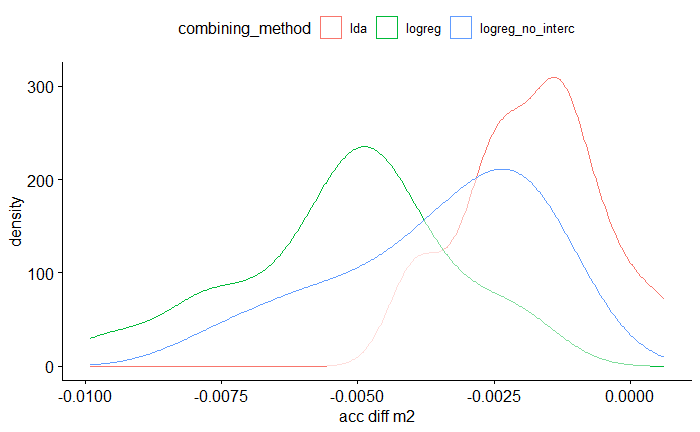

```r
ggdensity(data=differences, x="acc_diff_m2", color="combining_method", xlab="acc diff m2")
```

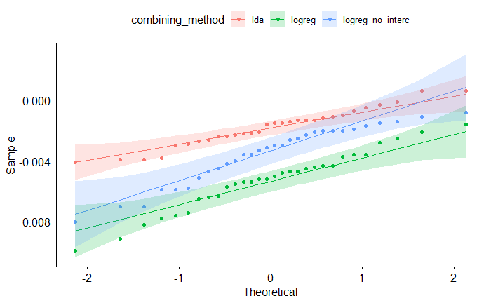

```r
ggqqplot(differences, x="acc_diff_m2", color="combining_method")
```

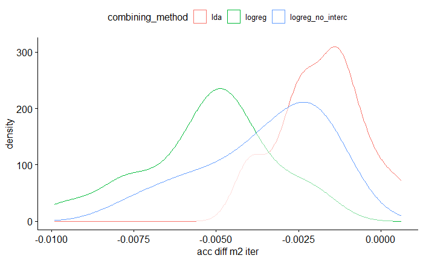

```r
ggdensity(data=differences, x="acc_diff_m2_iter", color="combining_method", xlab="acc diff m2 iter")
```

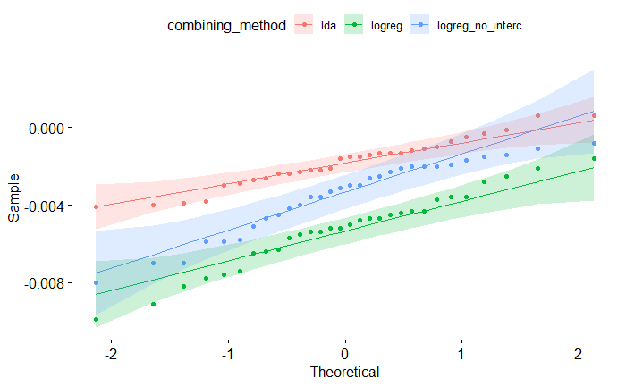

```r
ggqqplot(differences, x="acc_diff_m2_iter", color="combining_method")
```

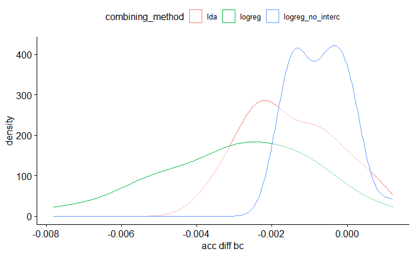

```r
ggdensity(data=differences, x="acc_diff_bc", color="combining_method", xlab="acc diff bc")
```

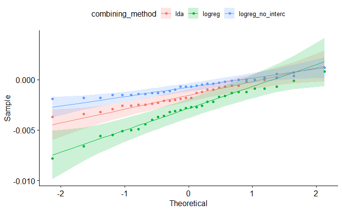

```r
ggqqplot(differences, x="acc_diff_bc", color="combining_method")
```

```r
shapiro.test(lda_diff$acc_diff_bc)
```

```
    Shapiro-Wilk normality test

data:  lda_diff$acc_diff_bc
W = 0.96681, p-value = 0.456
```

```r
logreg_diff <- differences %>% filter(combining_method=="logreg")
shapiro.test(logreg_diff$acc_diff_bc)
```

```
    Shapiro-Wilk normality test

data:  logreg_diff$acc_diff_bc
W = 0.98069, p-value = 0.8436
```

```r
logreg_ni_diff <- differences %>% filter(combining_method=="logreg_no_interc")
shapiro.test(logreg_ni_diff$acc_diff_bc)
```

```
    Shapiro-Wilk normality test

data:  logreg_ni_diff$acc_diff_bc
W = 0.96103, p-value = 0.329
```

Shapiro-Wilk zero hypothesis is data normality. Accuracy differences seem to be normal, so we can proceed with the t-tests.

### LDA

```r
ens_results_wide_lda <- ens_results_wide %>% filter(combining_method=="lda")
t.test(ens_results_wide_lda$accuracy_vt_m1, ens_results_wide_lda$accuracy_tt_m1, paired=TRUE)
```

```
    Paired t-test

data:  ens_results_wide_lda$accuracy_vt_m1 and ens_results_wide_lda$accuracy_tt_m1
t = -7.8715, df = 29, p-value = 1.11e-08
alternative hypothesis: true difference in means is not equal to 0
95 percent confidence interval:
 -0.002242492 -0.001317508
sample estimates:
mean of the differences
               -0.00178
```

```r
t.test(ens_results_wide_lda$accuracy_vt_m1, ens_results_wide_lda$accuracy_tt_m1, paired=TRUE, alternative="less")
```

```
    Paired t-test

data:  ens_results_wide_lda$accuracy_vt_m1 and ens_results_wide_lda$accuracy_tt_m1
t = -7.8715, df = 29, p-value = 5.551e-09
alternative hypothesis: true difference in means is less than 0
95 percent confidence interval:
         -Inf -0.001395773
sample estimates:
mean of the differences
               -0.00178
```

```r
t.test(ens_results_wide_lda$accuracy_vt_m2, ens_results_wide_lda$accuracy_tt_m2, paired=TRUE)
```

```
    Paired t-test

data:  ens_results_wide_lda$accuracy_vt_m2 and ens_results_wide_lda$accuracy_tt_m2
t = -7.8622, df = 29, p-value = 1.137e-08
alternative hypothesis: true difference in means is not equal to 0
95 percent confidence interval:
 -0.002272440 -0.001334227
sample estimates:
mean of the differences
           -0.001803333
```

```r
t.test(ens_results_wide_lda$accuracy_vt_m2, ens_results_wide_lda$accuracy_tt_m2, paired=TRUE, alternative="less")
```

```
    Paired t-test

data:  ens_results_wide_lda$accuracy_vt_m2 and ens_results_wide_lda$accuracy_tt_m2
t = -7.8622, df = 29, p-value = 5.684e-09
alternative hypothesis: true difference in means is less than 0
95 percent confidence interval:
         -Inf -0.001413611
sample estimates:
mean of the differences
           -0.001803333
```

```r
t.test(ens_results_wide_lda$accuracy_vt_m2_iter, ens_results_wide_lda$accuracy_tt_m2_iter, paired=TRUE)
```

```
    Paired t-test

data:  ens_results_wide_lda$accuracy_vt_m2_iter and ens_results_wide_lda$accuracy_tt_m2_iter
t = -7.8401, df = 29, p-value = 1.203e-08
alternative hypothesis: true difference in means is not equal to 0
95 percent confidence interval:
 -0.002277966 -0.001335367
sample estimates:
mean of the differences
           -0.001806667
```

```r
t.test(ens_results_wide_lda$accuracy_vt_m2_iter, ens_results_wide_lda$accuracy_tt_m2_iter, paired=TRUE, alternative="less")
```

```
    Paired t-test

data:  ens_results_wide_lda$accuracy_vt_m2_iter and ens_results_wide_lda$accuracy_tt_m2_iter
t = -7.8401, df = 29, p-value = 6.013e-09
alternative hypothesis: true difference in means is less than 0
95 percent confidence interval:
         -Inf -0.001415122
sample estimates:
mean of the differences
           -0.001806667
```

```r
t.test(ens_results_wide_lda$accuracy_vt_bc, ens_results_wide_lda$accuracy_tt_bc, paired=TRUE)
```

```
    Paired t-test

data:  ens_results_wide_lda$accuracy_vt_bc and ens_results_wide_lda$accuracy_tt_bc
t = -6.6405, df = 29, p-value = 2.794e-07
alternative hypothesis: true difference in means is not equal to 0
95 percent confidence interval:
 -0.001966353 -0.001040314
sample estimates:
mean of the differences
           -0.001503333
```

```r
t.test(ens_results_wide_lda$accuracy_vt_bc, ens_results_wide_lda$accuracy_tt_bc, paired=TRUE, alternative="less")
```

```
    Paired t-test

data:  ens_results_wide_lda$accuracy_vt_bc and ens_results_wide_lda$accuracy_tt_bc
t = -6.6405, df = 29, p-value = 1.397e-07
alternative hypothesis: true difference in means is less than 0
95 percent confidence interval:
         -Inf -0.001118668
sample estimates:
mean of the differences
           -0.001503333
```

### LogReg

```r
ens_results_wide_logreg <- ens_results_wide %>% filter(combining_method=="logreg")
t.test(ens_results_wide_logreg$accuracy_vt_m1, ens_results_wide_logreg$accuracy_tt_m1, paired=TRUE)
```

```
    Paired t-test

data:  ens_results_wide_logreg$accuracy_vt_m1 and ens_results_wide_logreg$accuracy_tt_m1
t = -13.458, df = 29, p-value = 5.324e-14
alternative hypothesis: true difference in means is not equal to 0
95 percent confidence interval:
 -0.005533312 -0.004073354
sample estimates:
mean of the differences
           -0.004803333
```

```r
t.test(ens_results_wide_logreg$accuracy_vt_m1, ens_results_wide_logreg$accuracy_tt_m1, paired=TRUE, alternative="less")
```

```
    Paired t-test

data:  ens_results_wide_logreg$accuracy_vt_m1 and ens_results_wide_logreg$accuracy_tt_m1
t = -13.458, df = 29, p-value = 2.662e-14
alternative hypothesis: true difference in means is less than 0
95 percent confidence interval:
         -Inf -0.004196884
sample estimates:
mean of the differences
           -0.004803333
```

```r
t.test(ens_results_wide_logreg$accuracy_vt_m2, ens_results_wide_logreg$accuracy_tt_m2, paired=TRUE)
```

```
    Paired t-test

data:  ens_results_wide_logreg$accuracy_vt_m2 and ens_results_wide_logreg$accuracy_tt_m2
t = -14.523, df = 29, p-value = 7.704e-15
alternative hypothesis: true difference in means is not equal to 0
95 percent confidence interval:
 -0.006015945 -0.004530722
sample estimates:
mean of the differences
           -0.005273333
```

```r
t.test(ens_results_wide_logreg$accuracy_vt_m2, ens_results_wide_logreg$accuracy_tt_m2, paired=TRUE, alternative="less")
```

```
    Paired t-test

data:  ens_results_wide_logreg$accuracy_vt_m2 and ens_results_wide_logreg$accuracy_tt_m2
t = -14.523, df = 29, p-value = 3.852e-15
alternative hypothesis: true difference in means is less than 0
95 percent confidence interval:
        -Inf -0.00465639
sample estimates:
mean of the differences
           -0.005273333
```

```r
t.test(ens_results_wide_logreg$accuracy_vt_m2_iter, ens_results_wide_logreg$accuracy_tt_m2_iter, paired=TRUE)
```

```
    Paired t-test

data:  ens_results_wide_logreg$accuracy_vt_m2_iter and ens_results_wide_logreg$accuracy_tt_m2_iter
t = -14.523, df = 29, p-value = 7.704e-15
alternative hypothesis: true difference in means is not equal to 0
95 percent confidence interval:
 -0.006015945 -0.004530722
sample estimates:
mean of the differences
           -0.005273333
```

```r
t.test(ens_results_wide_logreg$accuracy_vt_m2_iter, ens_results_wide_logreg$accuracy_tt_m2_iter, paired=TRUE, alternative="less")
```

```
    Paired t-test

data:  ens_results_wide_logreg$accuracy_vt_m2_iter and ens_results_wide_logreg$accuracy_tt_m2_iter
t = -14.523, df = 29, p-value = 3.852e-15
alternative hypothesis: true difference in means is less than 0
95 percent confidence interval:
        -Inf -0.00465639
sample estimates:
mean of the differences
           -0.005273333
```

```r
t.test(ens_results_wide_logreg$accuracy_vt_bc, ens_results_wide_logreg$accuracy_tt_bc, paired=TRUE)
```

```
    Paired t-test

data:  ens_results_wide_logreg$accuracy_vt_bc and ens_results_wide_logreg$accuracy_tt_bc
t = -8.1519, df = 29, p-value = 5.464e-09
alternative hypothesis: true difference in means is not equal to 0
95 percent confidence interval:
 -0.003731823 -0.002234844
sample estimates:
mean of the differences
           -0.002983333
```

```r
t.test(ens_results_wide_logreg$accuracy_vt_bc, ens_results_wide_logreg$accuracy_tt_bc, paired=TRUE, alternative="less")
```

```
    Paired t-test

data:  ens_results_wide_logreg$accuracy_vt_bc and ens_results_wide_logreg$accuracy_tt_bc
t = -8.1519, df = 29, p-value = 2.732e-09
alternative hypothesis: true difference in means is less than 0
95 percent confidence interval:
         -Inf -0.002361506
sample estimates:
mean of the differences
           -0.002983333
```

### LogReg without intercept

```r
ens_results_wide_logreg_ni <- ens_results_wide %>% filter(combining_method=="logreg_no_interc")
t.test(ens_results_wide_logreg_ni$accuracy_vt_m1, ens_results_wide_logreg_ni$accuracy_tt_m1, paired=TRUE)
```

```
    Paired t-test

data:  ens_results_wide_logreg_ni$accuracy_vt_m1 and ens_results_wide_logreg_ni$accuracy_tt_m1
t = -9.0337, df = 29, p-value = 6.281e-10
alternative hypothesis: true difference in means is not equal to 0
95 percent confidence interval:
 -0.003499328 -0.002207339
sample estimates:
mean of the differences
           -0.002853333
```

```r
t.test(ens_results_wide_logreg_ni$accuracy_vt_m1, ens_results_wide_logreg_ni$accuracy_tt_m1, paired=TRUE, alternative="less")
```

```
    Paired t-test

data:  ens_results_wide_logreg_ni$accuracy_vt_m1 and ens_results_wide_logreg_ni$accuracy_tt_m1
t = -9.0337, df = 29, p-value = 3.141e-10
alternative hypothesis: true difference in means is less than 0
95 percent confidence interval:
         -Inf -0.002316657
sample estimates:
mean of the differences
           -0.002853333
```

```r
t.test(ens_results_wide_logreg_ni$accuracy_vt_m2, ens_results_wide_logreg_ni$accuracy_tt_m2, paired=TRUE)
```

```
    Paired t-test

data:  ens_results_wide_logreg_ni$accuracy_vt_m2 and ens_results_wide_logreg_ni$accuracy_tt_m2
t = -10.026, df = 29, p-value = 6.215e-11
alternative hypothesis: true difference in means is not equal to 0
95 percent confidence interval:
 -0.00423802 -0.00280198
sample estimates:
mean of the differences
               -0.00352
```

```r
t.test(ens_results_wide_logreg_ni$accuracy_vt_m2, ens_results_wide_logreg_ni$accuracy_tt_m2, paired=TRUE, alternative="less")
```

```
    Paired t-test

data:  ens_results_wide_logreg_ni$accuracy_vt_m2 and ens_results_wide_logreg_ni$accuracy_tt_m2
t = -10.026, df = 29, p-value = 3.108e-11
alternative hypothesis: true difference in means is less than 0
95 percent confidence interval:
         -Inf -0.002923486
sample estimates:
mean of the differences
               -0.00352
```

```r
t.test(ens_results_wide_logreg_ni$accuracy_vt_m2_iter, ens_results_wide_logreg_ni$accuracy_tt_m2_iter, paired=TRUE)
```

```
    Paired t-test

data:  ens_results_wide_logreg_ni$accuracy_vt_m2_iter and ens_results_wide_logreg_ni$accuracy_tt_m2_iter
t = -10.026, df = 29, p-value = 6.215e-11
alternative hypothesis: true difference in means is not equal to 0
95 percent confidence interval:
 -0.00423802 -0.00280198
sample estimates:
mean of the differences
               -0.00352
```

```r
t.test(ens_results_wide_logreg_ni$accuracy_vt_m2_iter, ens_results_wide_logreg_ni$accuracy_tt_m2_iter, paired=TRUE, alternative="less")
```

```
    Paired t-test

data:  ens_results_wide_logreg_ni$accuracy_vt_m2_iter and ens_results_wide_logreg_ni$accuracy_tt_m2_iter
t = -10.026, df = 29, p-value = 3.108e-11
alternative hypothesis: true difference in means is less than 0
95 percent confidence interval:
         -Inf -0.002923486
sample estimates:
mean of the differences
               -0.00352
```

```r
t.test(ens_results_wide_logreg_ni$accuracy_vt_bc, ens_results_wide_logreg_ni$accuracy_tt_bc, paired=TRUE)
```

```
    Paired t-test

data:  ens_results_wide_logreg_ni$accuracy_vt_bc and ens_results_wide_logreg_ni$accuracy_tt_bc
t = -5.0961, df = 29, p-value = 1.942e-05
alternative hypothesis: true difference in means is not equal to 0
95 percent confidence interval:
 -0.0009949435 -0.0004250565
sample estimates:
mean of the differences
               -0.00071
```

```r
t.test(ens_results_wide_logreg_ni$accuracy_vt_bc, ens_results_wide_logreg_ni$accuracy_tt_bc, paired=TRUE, alternative="less")
```

```
    Paired t-test

data:  ens_results_wide_logreg_ni$accuracy_vt_bc and ens_results_wide_logreg_ni$accuracy_tt_bc
t = -5.0961, df = 29, p-value = 9.709e-06
alternative hypothesis: true difference in means is less than 0
95 percent confidence interval:
          -Inf -0.0004732759
sample estimates:
mean of the differences
               -0.00071
```

For all combining methods and for all coupling methods, we found, that ensemble models trained on subset (of size 500) of the neural networks training set have statistically significantly better accuracy than ensemble models trained on separate validation set (of the same size).

## Negative log likelihood

Ascertaining normality of differences

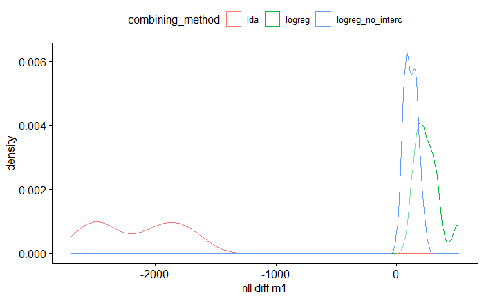

```r
ggdensity(data=differences, x="nll_diff_m1", color="combining_method", xlab="nll diff m1")
```

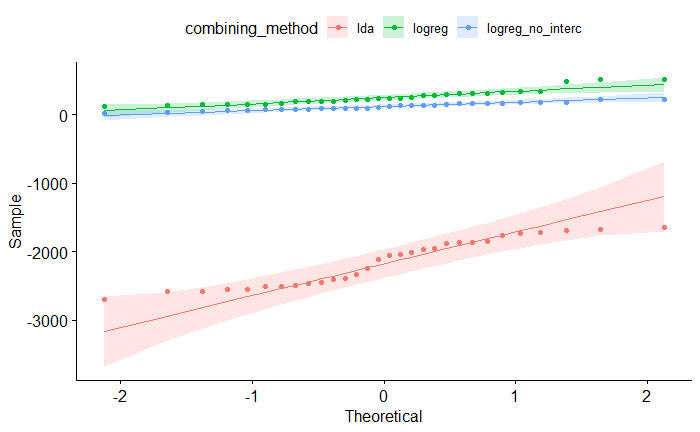

```r
ggqqplot(differences, x="nll_diff_m1", color="combining_method")
```

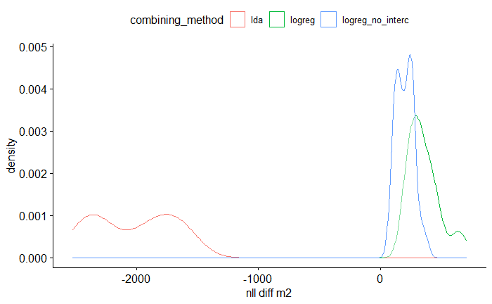

```r
ggdensity(data=differences, x="nll_diff_m2", color="combining_method", xlab="nll diff m2")
```

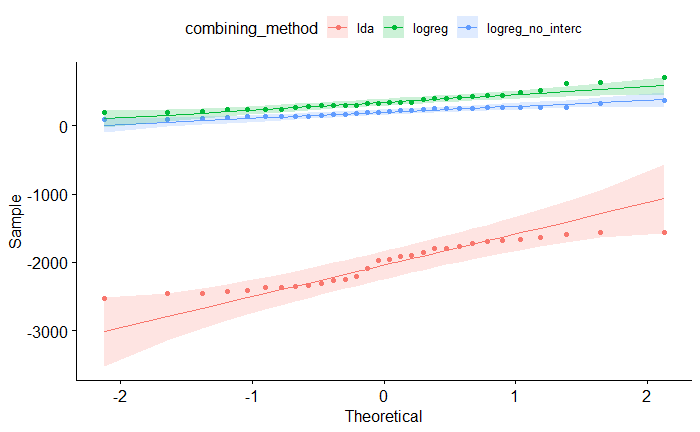

```r
ggqqplot(differences, x="nll_diff_m2", color="combining_method")
```

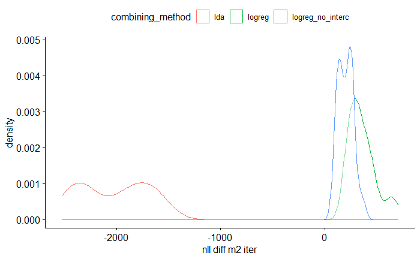

```r
ggdensity(data=differences, x="nll_diff_m2_iter", color="combining_method", xlab="nll diff m2 iter")
```

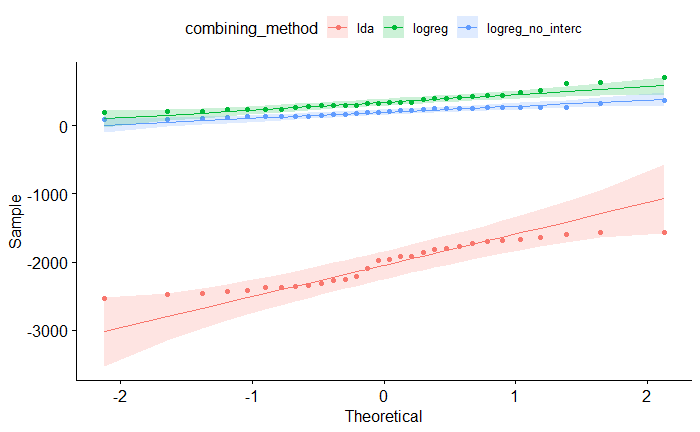

```r
ggqqplot(differences, x="nll_diff_m2_iter", color="combining_method")
```

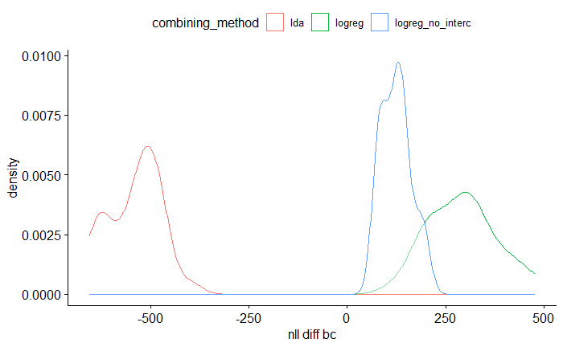

```r
ggdensity(data=differences, x="nll_diff_bc", color="combining_method", xlab="nll diff bc")
```

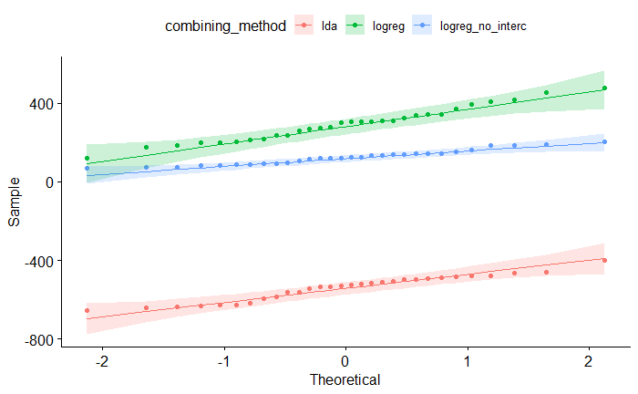

```r
ggqqplot(differences, x="nll_diff_bc", color="combining_method")
```

Differences don’t seem to be normal in several cases. We postpone tests on this secondary metric.